# Introduction to linear regression

1. What type of plot would you use to display the relationship between `runs` and one of the other numerical variables? Plot this relationship using the variable `at_bats` as the predictor. Does the relationship look linear? If you knew a team’s `at_bats`, would you be comfortable using a linear model to predict the number of runs?

*I’d use a scatterplot*.

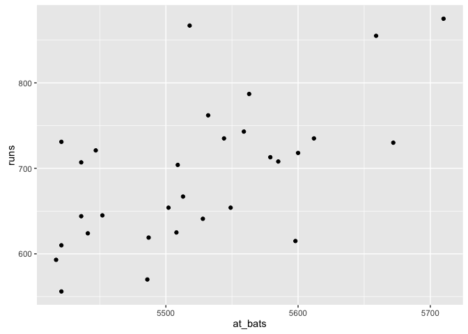

```r
qplot(x = at_bats, y = runs, data = mlb11)
```

*There appears to be a linear relationship between these variables.*

2. Looking at your plot from the previous exercise, describe the relationship between these two variables. Make sure to discuss the form, direction, and strength of the relationship as well as any unusual observations.

*There appears to be a weak to moderate relationship between these variables that is positive and linear. There are no egregious unusual observations, though a potential outlider with `at_bats` just above 5500 and `runs` above 850.*

3. Using `plot_ss`, choose a line that does a good job of minimizing the sum of squares. Run the function several times. What was the smallest sum of squares that you got? How does it compare to your neighbors?

*Answers will vary here. Something like this is what we are looking for: The smallest sum of squares that I got was 129750.5, but my neighbors were able to get around 126,000 and around 127,000.*

4. Fit a new model that uses `homeruns` to predict `runs`. Using the estimates from the R output, write the equation of the regression line. What does the slope tell us in the context of the relationship between success of a team and its home runs?

```r
m1 <- lm(runs ~ homeruns, data = mlb11)
summary(m1)
```

```
##
## Call:
## lm(formula = runs ~ homeruns, data = mlb11)
##
## Residuals:
##    Min     1Q Median     3Q    Max
## -91.61 -33.41   3.23  24.29 104.63
##
## Coefficients:
##             Estimate Std. Error t value Pr(>|t|)
## (Intercept)  415.239     41.678    9.96  1.0e-10 ***
## homeruns       1.835      0.268    6.85  1.9e-07 ***
## ---
## Signif. codes:  0 '***' 0.001 '**' 0.01 '*' 0.05 '.' 0.1 ' ' 1
##
## Residual standard error: 51.3 on 28 degrees of freedom
## Multiple R-squared:  0.627,  Adjusted R-squared:  0.613
## F-statistic:   47 on 1 and 28 DF,  p-value: 1.9e-07
```

$$\widehat{runs} = 415.2389 + 1.8345 \times homeruns$$

*The slope tells us that we’d expect a team that scores one more homerun in a season to score about 1.8 more runs, on average.*

5. If a team manager saw the least squares regression line and not the actual data, how many runs would he or she predict for a team with 5,578 at-bats? Is this an overestimate or an underestimate, and by how much? In other words, what is the residual for this prediction?

```r
ma <- lm(runs ~ at_bats, data = mlb11)
(y_hat <- coef(ma)[1] + coef(ma)[2] * 5578)
```

```
## (Intercept)
##         728
```

*Based on our regression model, we could predict that a team with 5,578 at bats would score 727.965 runs in a season. In our data set, the Philadelpha Phillies had 5,579 at bats (so we use that as a proxy for an observed 5578 at bats runs total), so their residual indicates that they underperformed (our model overestimated their performance).*

```r
y_obs <- filter(mlb11, at_bats == 5579) %>% select(runs)
y_obs - y_hat
```

```
##     runs
## 1 -14.96
```

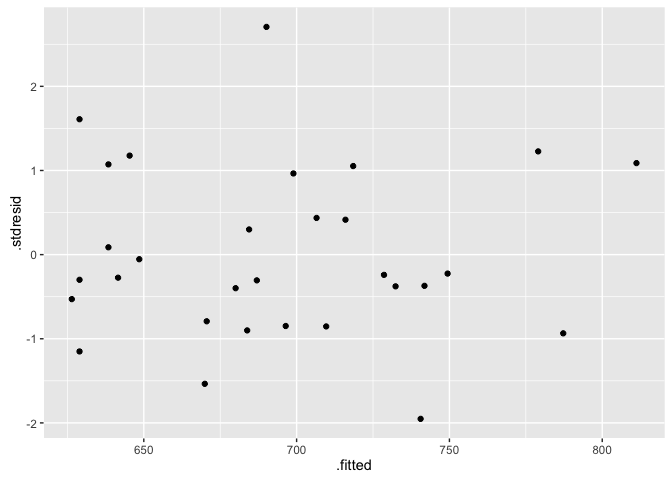

```r
qplot(x = .fitted, y = .stdresid, data = ma)
```

6. Is there any apparent pattern in the residuals plot? What does this indicate about the linearity of the relationship between runs and at-bats?

*There is no strong non-linearity in this residual plot, which indicates that the assumption of a linear trend between the x and the y is reasonable.*

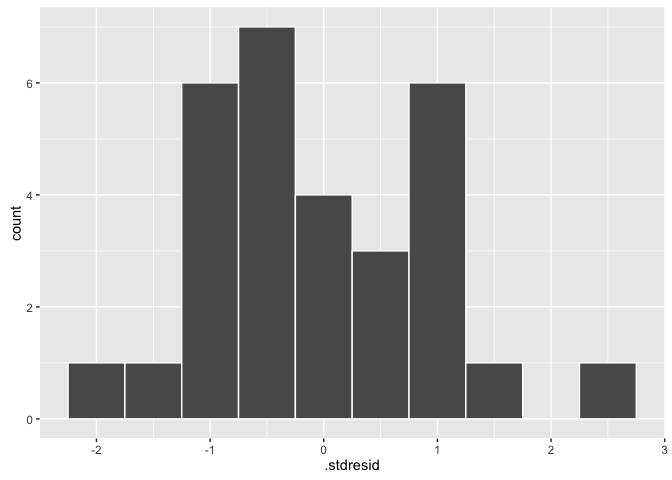

```r
qplot(x = .stdresid, data = ma, geom = "histogram", binwidth = 0.5, col = I("white"))
```

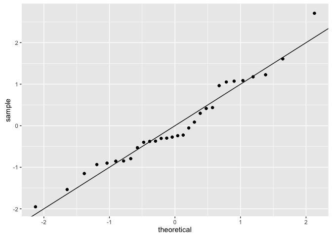

```r
qplot(sample = .stdresid, data = ma) + stat_qq() +
  geom_abline()
```

7. Based on the histogram and the normal probability plot, does the nearly normal residuals condition appear to be met?

*Although there are some deviations from the line, it’s reasonable to conclude that our residuals have come from a normal distribution.*

8. Based on the plot for the linearity condition, does the constant variability condition appear to be met?

*It is tempting to conclude that because there are fewer small residuals at the higher fitted values, that variance has increased. However, this could well be explained by the fewer observations we have at those higher values. There are no strong indications of non-constant variance.*

## On Your Own

- Choose another one of the seven traditional variables from `mlb11` besides `at_bats` that you think might be a good predictor of `runs`. Produce a scatterplot of the two variables and fit a linear model. At a glance, does there seem to be a linear relationship?

*I’ll choose to look at `stolen_bases`*

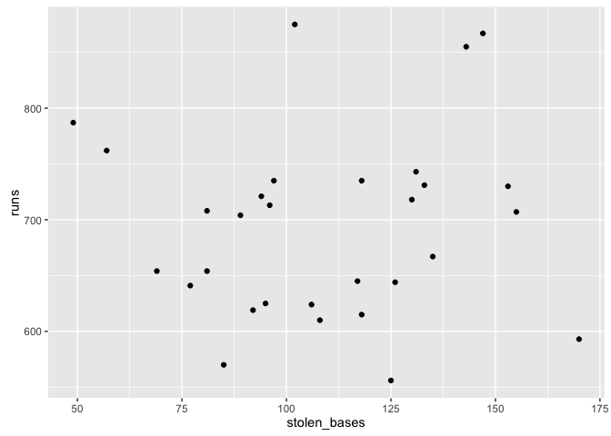

```r
qplot(x = stolen_bases, y = runs, data = mlb11)
```

*The linear relationship doesn’t seem unreasonable here, but it’s clear any relationship is very weak.*

- How does this relationship compare to the relationship between `runs` and `at_bats`? Use the R$^2$ values from the two model summaries to compare. Does your variable seem to predict `runs` better than `at_bats`? How can you tell?

```r
m2 <- lm(runs ~ stolen_bases, data = mlb11)
rsq2 <- summary(m2)$r.squared
rsqa <- summary(ma)$r.squared
```

*It’s clear that `at_bats` is a far better predictor than `stolen_bases`. The `at_bats` model has an $R^2$ value of 0.3729 and the `stolen_bases` model has an $R^2$ of 0.0029.*

- Now that you can summarize the linear relationship between two variables, investigate the relationships between `runs` and each of the other five traditional variables. Which variable best predicts `runs`? Support your conclusion using the graphical and numerical methods we’ve discussed (for the sake of conciseness, only include output for the best variable, not all five).

*The strongest predictor is `bat_avg`.*

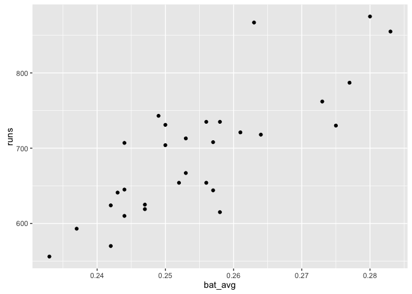

```r
qplot(x = bat_avg, y = runs, data = mlb11)
```

```r
m3 <- lm(runs ~ bat_avg, data = mlb11)
rsq3 <- summary(m3)$r.squared
```

*The $R^2$ value for this model is 0.6561, which narrowly edges out some of the other variables. The scatterplot shows that a linear trend is also sensible for prediction.*

- Now examine the three newer variables. These are the statistics used by the author of *Moneyball* to predict a teams success. In general, are they more or less effective at predicting runs that the old variables? Explain using appropriate graphical and numerical evidence. Of all ten variables we’ve analyzed, which seems to be the best predictor of `runs`? Using the limited (or not so limited) information you know about these baseball statistics, does your result make sense?

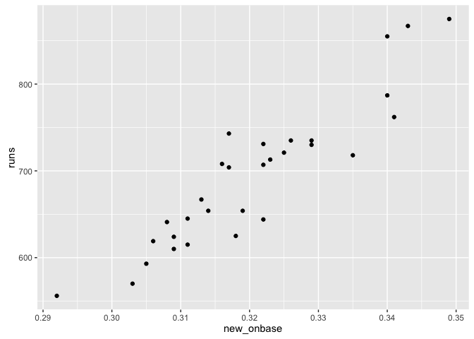

```r
qplot(x = new_onbase, y = runs, data = mlb11)
```

```r
m4 <- lm(runs ~ new_onbase, data = mlb11)
summary(m4)$r.squared
```

```
## [1] 0.8491
```

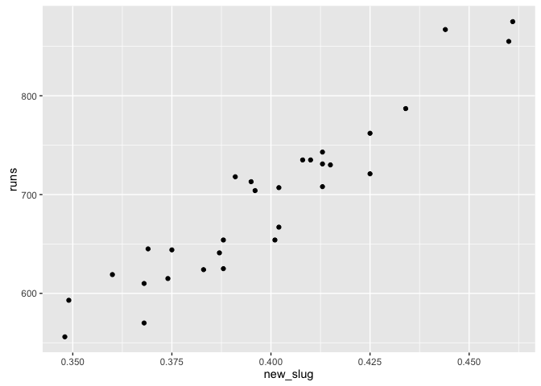

```r
qplot(x = new_slug, y = runs, data = mlb11)
```

```r
m5 <- lm(runs ~ new_slug, data = mlb11)
summary(m5)$r.squared
```

```
## [1] 0.8969
```

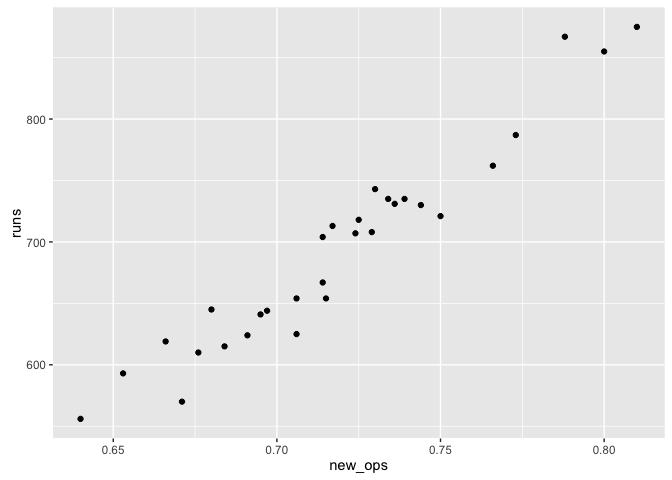

```r
qplot(x = new_ops, y = runs, data = mlb11)
```

```r
m6 <- lm(runs ~ new_ops, data = mlb11)
rsq6 <- summary(m6)$r.squared
```

*The new predictors are MUCH better than the originals for predicting the number of runs that a team will score in a season. The best predictor was `new_ops` with an $R^2$ of 0.9349. I don’t know much about baseball, so it’s tough to assess if this makes sense, but in general, if you can develop a metric that involves multiple sources of information, it should be able to do a better job of prediction.*

- Check the model diagnostics for the regression model with the variable you decided was the best predictor for runs.

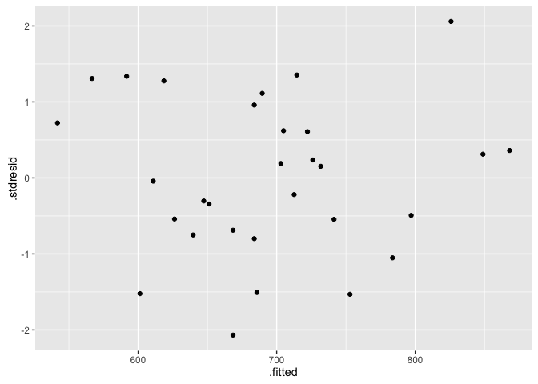

```r
qplot(x = .fitted, y = .stdresid, data = m6)
```

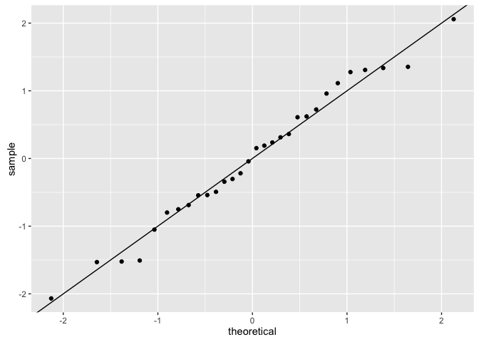

```r
qplot(sample = .stdresid, data = m6) +
  geom_abline()
```

*The residual plot shows that our assumptions of a linear trend with constant variance in the residuals are reasonable. The qqplot shows some small deviations from the line, but it’s still in line with what we’d expect if we had normally distributed errors.*

This is a product of OpenIntro that is released under a [Creative Commons Attribution-ShareAlike 3.0 Unported](http://creativecommons.org/licenses/by-sa/3.0). This lab was adapted for OpenIntro by Andrew Bray, Chester Ismay, and Mine Çetinkaya-Rundel from a lab written by the faculty and TAs of UCLA Statistics.